# Clinical Significance Plots

Benedikt Claus

08-12-2022

Clinical significance results can be presented in tabular form and as figures. Figures are especially informative and can be used to understand the different clinical significance categories.

Let’s consider the fictitious data set `anxiety`. This data set contains anxiety scores of 116 subjects assessed at five measurements during a psychological intervention. Measurement 0 corresponds to the pre intervention and measurement 4 to the post intervention assessment. Furthermore, the sample is grouped into two experimental conditions (Placebo vs. Intervention).

```r
library(clinicalsignificance)

anxiety
```

```
#> # A tibble: 580 × 4
#>    subject treatment    measurement anxiety
#>    <chr>   <fct>              <dbl>   <dbl>
#>  1 S001    Placebo                0    36.2
#>  2 S001    Placebo                1    32.4
#>  3 S001    Placebo                2    35.9
#>  4 S001    Placebo                3    32.6
#>  5 S001    Placebo                4    NA
#>  6 S002    Intervention           0    30.1
#>  7 S002    Intervention           1    28.3
#>  8 S002    Intervention           2    34.0
#>  9 S002    Intervention           3    33.1
#> 10 S002    Intervention           4    33.8
#> # … with 570 more rows
```

## Clinical Significance Plot

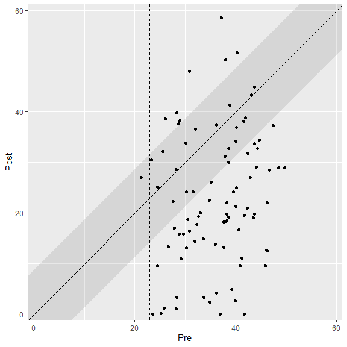

```r
anxiety_results <- anxiety %>%
  clinical_significance(
    id = subject,
    time = measurement,
    outcome = anxiety,
    pre = 0,
    post = 4,
    reliability = 0.80,
    m_functional = 10,
    sd_functional = 7,
    type = "c"
  )

plot(anxiety_results, upper_limit = 60)
```

## Interpretation

If a lower instrument score corresponds to a beneficial outcome, then the categories in a clinical significance plot can be interpreted according to the figure below.

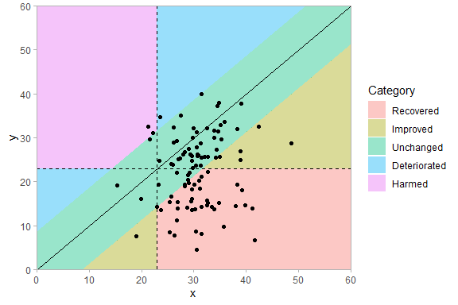

If a higher instrument score corresponds to a beneficial outcome, then the categories in a clinical significance plot can be interpreted according to the figure below. This is the same plot as above, but flipped along the diagonal that indicates no change.

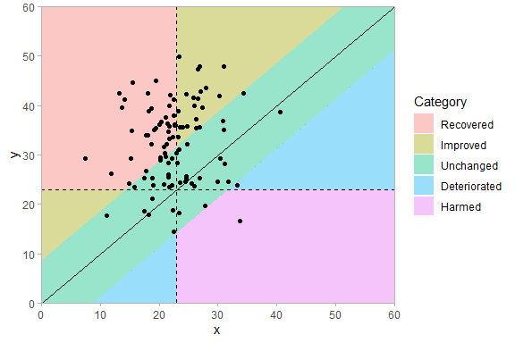

## Different Methods

The plot automatically changes according to the specified clinical significance method.

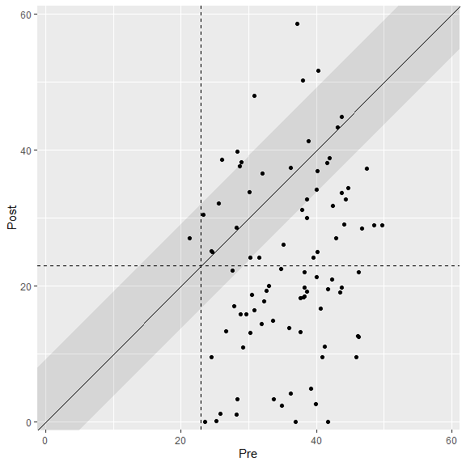

```r
anxiety_results_ha <- anxiety %>%
  clinical_significance(
    id = subject,
    time = measurement,
    outcome = anxiety,
    pre = 0,
    post = 4,
    reliability = 0.80,
    m_functional = 10,
    sd_functional = 7,
    type = "c",
    method = "HA"
  )

plot(anxiety_results_ha, upper_limit = 60)
```

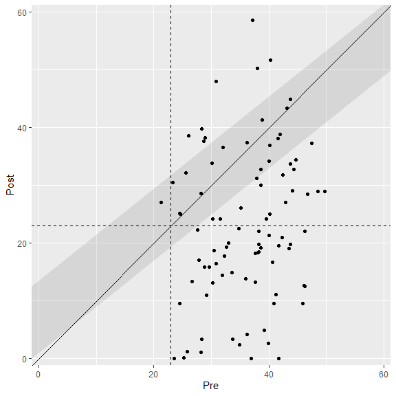

```r
anxiety_results_en <- anxiety %>%
  clinical_significance(
    id = subject,
    time = measurement,
    outcome = anxiety,
    pre = 0,
    post = 4,
    reliability = 0.80,
    m_functional = 10,
    sd_functional = 7,
    type = "c",
    method = "EN"
  )

plot(anxiety_results_en, upper_limit = 60)
```

For clinical significance analyses employing the HLM method (Raudenbush & Bryk, 2002), individual trajectories can be plotted as well.

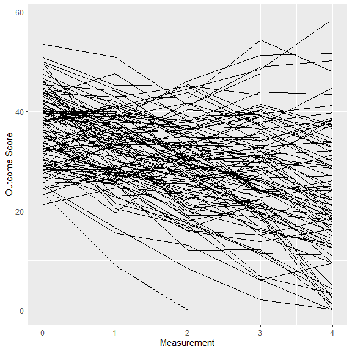

```r
anxiety_results_hlm <- anxiety %>%
  clinical_significance(
    id = subject,
    time = measurement,
    outcome = anxiety,
    method = "HLM"
  )

plot(anxiety_results_hlm, which = "trajectory")
```

## Plot Options

### Colors

You can choose different categories or groups to be colored separately. If you clinical significance analysis contains a grouping variable, this is automatically shown in the corresponding plot.

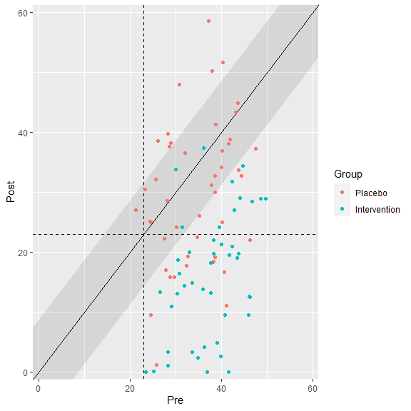

```r
anxiety_results_grouped <- anxiety %>%
  clinical_significance(
    id = subject,
    time = measurement,
    outcome = anxiety,
    pre = 0,
    post = 4,
    reliability = 0.80,
    m_functional = 10,
    sd_functional = 7,
    type = "c",
    group = treatment
  )

plot(anxiety_results_grouped, upper_limit = 60)
```

Alternatively, you can color the individual clinical significance categories.

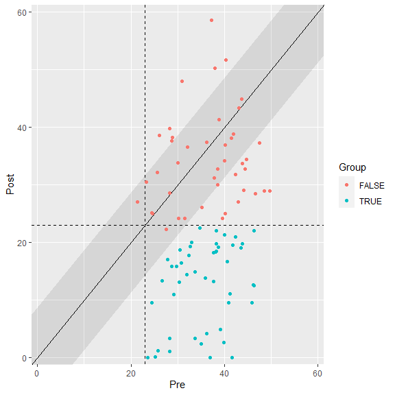

```r
plot(anxiety_results, upper_limit = 60, show = recovered)
```

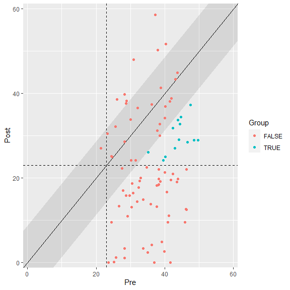

```r
plot(anxiety_results, upper_limit = 60, show = improved)
```

Or all categories at once.

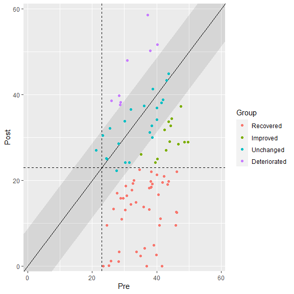

```r
plot(anxiety_results, upper_limit = 60, show = category)
```

Trajectories for the HLM can be colored as well.

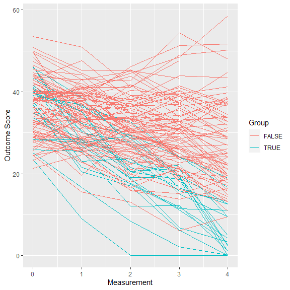

```r
plot(anxiety_results_hlm, which = "trajectory", show = recovered)
```

Because `clinicalsignificance` uses ggplot2 internally, you can manipulate plots to your liking.

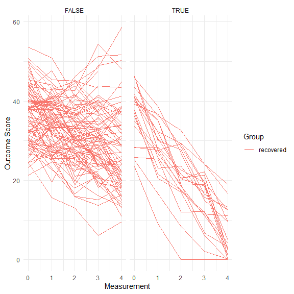

```r
plot(anxiety_results_hlm, which = "trajectory", show = "recovered") +
  facet_wrap(~ recovered) +
  theme_minimal()
```

### RCI Fill

You can change the display of the RCI band, i.e., its color and transparency.

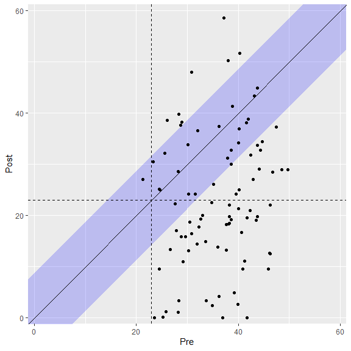

```r
plot(anxiety_results, upper_limit = 60, rci_fill = "blue", rci_alpha = 0.2)
```

The HA method (Hageman & Arrindell, 1999) considers a band around the post measurement cutoff, which can be plotted as well.

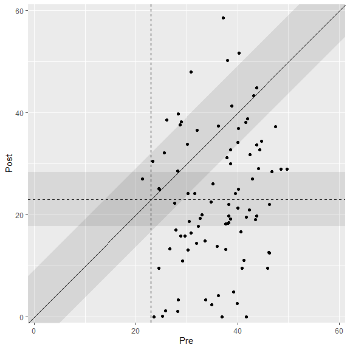

```r
plot(anxiety_results_ha, upper_limit = 60, include_cutoff_band = TRUE)
```

### Cutoffs

It is recommended to include the cutoff between the clinical and functional population. By default, they are plotted but can be omitted as well.

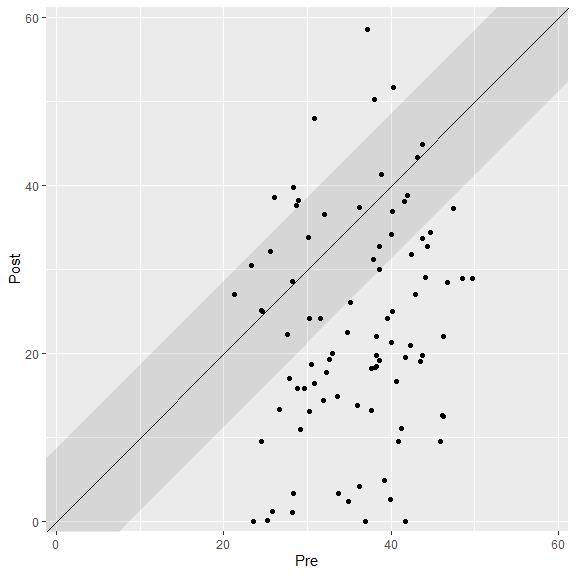

```r
plot(anxiety_results, upper_limit = 60, include_cutoff = FALSE)
```

### Labels

By default, only generic plot labels are used. You can adjust them to make the figure publication ready.

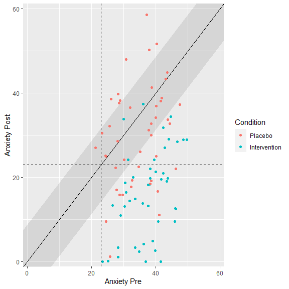

```r
plot(anxiety_results_grouped,
     upper_limit = 60,
     x_lab = "Anxiety Pre",
     y_lab = "Anxiety Post",
     color_lab = "Condition")
```

## References

Hageman, W. J., & Arrindell, W. A. (1999). plotEstablishing clinically significant change: increment of precision and the distinction between individual and group level analysis. *Behaviour Research and Therapy*, *37*(12), 1169–1193. https://doi.org/10.1016/S0005-7967(99)00032-7

Raudenbush, S. W., & Bryk, A. S. (2002). *Hierarchical Linear Models - Applications and Data Analysis Methods* (2nd ed.). Sage Publications.